# Example regression analysis: Party preference and ideological orientation

## Pooled Cross Sections

We estimate the following model with the quadratic function:

```r
summary(lm.out.dummy <- lm(skalo.true ~ lr.dist.abs + lr.dist.sqr + as.factor(party)
                           ,data=long.data))
```

```
##
## Call:
## lm(formula = skalo.true ~ lr.dist.abs + lr.dist.sqr + as.factor(party),
##     data = long.data)
##
## Residuals:
##     Min      1Q  Median      3Q     Max
## -8.2664 -1.2635  0.0597  1.2709  9.4194
##
## Coefficients:
##                     Estimate Std. Error t value Pr(>|t|)
## (Intercept)        2.7216632  0.1090836  24.950  < 2e-16 ***
## lr.dist.abs       -1.2064036  0.0456256 -26.441  < 2e-16 ***
## lr.dist.sqr        0.0573810  0.0058205   9.858  < 2e-16 ***
## as.factor(party)2 -0.5107611  0.1181026  -4.325 1.57e-05 ***
## as.factor(party)3  0.5615458  0.1194341   4.702 2.67e-06 ***
## as.factor(party)4  1.3882967  0.1205298  11.518  < 2e-16 ***
## as.factor(party)5 -0.1029053  0.1179475  -0.872    0.383
## as.factor(party)6 -2.2475507  0.1373943 -16.358  < 2e-16 ***
## as.factor(party)7  0.0003671  0.1166602   0.003    0.997
## ---
## Signif. codes:  0 '***' 0.001 '**' 0.01 '*' 0.05 '.' 0.1 ' ' 1
##
## Residual standard error: 1.944 on 3824 degrees of freedom
## Multiple R-squared:  0.6362, Adjusted R-squared:  0.6355
## F-statistic: 836.1 on 8 and 3824 DF,  p-value: < 2.2e-16
```

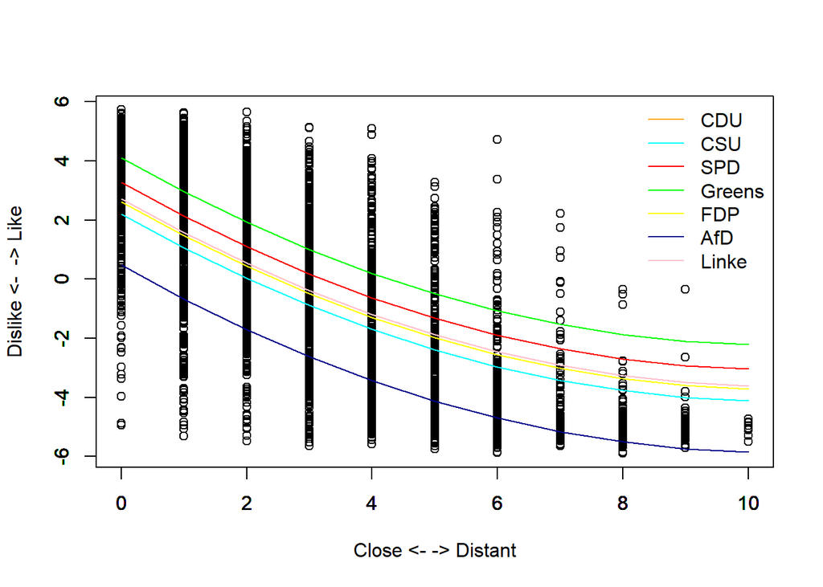

```r
plot(long.data$skalo.true ~ long.data$lr.dist.abs,
     xlab="Close <- -> Distant",ylab="Dislike <-  -> Like",
     xlim=range(long.data$lr.dist.abs,na.rm=T),
     ylim=range(long.data$skalo.true,na.rm=T))

predicted.cdu <- coef(lm.out.dummy)[1] + coef(lm.out.dummy)[2]*c(0:10)+ coef(lm.out.dummy)[3]* (c(0:10))^2
predicted.csu <- coef(lm.out.dummy)[1] + coef(lm.out.dummy)[2]*c(0:10) +coef(lm.out.dummy)[3]* (c(0:10))^2 +coef(lm.out.dummy)[4]
predicted.spd <- coef(lm.out.dummy)[1] + coef(lm.out.dummy)[2]*c(0:10) +coef(lm.out.dummy)[3]* (c(0:10))^2 +coef(lm.out.dummy)[5]
predicted.gru <- coef(lm.out.dummy)[1] + coef(lm.out.dummy)[2]*c(0:10) +coef(lm.out.dummy)[3]* (c(0:10))^2 +coef(lm.out.dummy)[6]
predicted.fdp <- coef(lm.out.dummy)[1] + coef(lm.out.dummy)[2]*c(0:10) +coef(lm.out.dummy)[3]* (c(0:10))^2 +coef(lm.out.dummy)[7]
predicted.afd <- coef(lm.out.dummy)[1] + coef(lm.out.dummy)[2]*c(0:10) +coef(lm.out.dummy)[3]* (c(0:10))^2 +coef(lm.out.dummy)[8]
predicted.lin <- coef(lm.out.dummy)[1] + coef(lm.out.dummy)[2]*c(0:10) +coef(lm.out.dummy)[3]* (c(0:10))^2 +coef(lm.out.dummy)[9]

par(new=T)
plot(predicted.cdu ~ c(0:10),col="orange",type="l",
     ann=F,axes=F,xlab="",ylab="",
     xlim=range(long.data$lr.dist.abs,na.rm=T),
     ylim=range(long.data$skalo.true,na.rm=T))
par(new=T)
plot(predicted.csu ~ c(0:10),col="cyan",type="l",
     ann=F,axes=F,xlab="",ylab="",
     xlim=range(long.data$lr.dist.abs,na.rm=T),
     ylim=range(long.data$skalo.true,na.rm=T))
par(new=T)
plot(predicted.spd ~ c(0:10),col="red",type="l",
     ann=F,axes=F,xlab="",ylab="",
     xlim=range(long.data$lr.dist.abs,na.rm=T),
     ylim=range(long.data$skalo.true,na.rm=T))
par(new=T)
plot(predicted.gru ~ c(0:10),col="green",type="l",
     ann=F,axes=F,xlab="",ylab="",
     xlim=range(long.data$lr.dist.abs,na.rm=T),
     ylim=range(long.data$skalo.true,na.rm=T))
par(new=T)
plot(predicted.fdp ~ c(0:10),col="yellow",type="l",
     ann=F,axes=F,xlab="",ylab="",
     xlim=range(long.data$lr.dist.abs,na.rm=T),
     ylim=range(long.data$skalo.true,na.rm=T))
par(new=T)
plot(predicted.afd ~ c(0:10),col="blue4",type="l",
     ann=F,axes=F,xlab="",ylab="",
     xlim=range(long.data$lr.dist.abs,na.rm=T),
     ylim=range(long.data$skalo.true,na.rm=T))
par(new=T)
plot(predicted.lin ~ c(0:10),col="pink",type="l",
     ann=F,axes=F,xlab="",ylab="",
     xlim=range(long.data$lr.dist.abs,na.rm=T),
     ylim=range(long.data$skalo.true,na.rm=T))


legend("topright",col=c("orange","cyan","red","green","yellow","blue4","pink"),
       lty=c(rep(1,8)),c("CDU","CSU","SPD","Greens","FDP","AfD",
                        "Linke"),
       lwd=c(rep(1,8)),
       bty="n")
```

Let’s look at the data again:

```r
head(long.data[,1:7],n=20)
```

```
##       id wave party skalo lr.self lr time
## 1  10131    3     1     3       1  1   63
## 2  10132    3     2     3       1  2   27
## 3  10133    3     3     2       1 -1   66
## 4  10134    3     4    -2       1 -2  105
## 5  10135    3     5     1       1  0   38
## 6  10136    3     6    -2       1  3   88
## 7  10137    3     7    -2       1 -4   28
## 8  10231    3     1     0       0  1   73
## 9  10232    3     2     0       0  1   19
## 10 10233    3     3     0       0 -1   53
## 11 10234    3     4     1       0 -2   34
## 12 10235    3     5     4       0  0   42
## 13 10236    3     6    -4       0  4   84
## 14 10237    3     7    -4       0 -4   40
## 15 10411    1     1     2       2  2   54
## 16 10416    1     6     1       2  5   20
## 17 10421    2     1     2       2  1   26
## 18 10422    2     2     1       2  0   89
## 19 10423    2     3     0       2 -2   37
## 20 10424    2     4    -1       2 -3   42
```

There is a variable “wave” which codes the time point of data collection:

```r
table(long.data$wave)
```

```
##
##    1    2    3
## 1303 1200 1330
```

According to the frequency table, the data were collected at three different time points. That is, we pooled three cross sections.

We might be interested whether the relationship between party evaluation and ideological distance is different at the three time points. One possibility is to estimate different regression models for each time point and compare them with the overall regression (the Chow test). Here, we add the interaction effects with the dummy variable for the panel waves. This is equivalent to estimate three separate regression models:

```r
summary(lm.out.chow <- lm(skalo.true ~ lr.dist.abs* as.factor(wave) +
                             lr.dist.sqr* as.factor(wave) +
                             as.factor(party)* as.factor(wave) ,data=long.data))
```

```
##
## Call:
## lm(formula = skalo.true ~ lr.dist.abs * as.factor(wave) + lr.dist.sqr *
##     as.factor(wave) + as.factor(party) * as.factor(wave), data = long.data)
##
## Residuals:
##     Min      1Q  Median      3Q     Max
## -8.1774 -1.1864  0.0511  1.2058  9.2650
##
## Coefficients:
##                                     Estimate Std. Error t value Pr(>|t|)
## (Intercept)                         3.240880   0.185694  17.453  < 2e-16 ***
## lr.dist.abs                        -1.184191   0.076308 -15.519  < 2e-16 ***
## as.factor(wave)2                   -0.226639   0.266339  -0.851  0.39486
## as.factor(wave)3                   -1.247385   0.259291  -4.811 1.56e-06 ***
## lr.dist.sqr                         0.050942   0.009647   5.281 1.36e-07 ***
## as.factor(party)2                  -0.625045   0.199293  -3.136  0.00172 **
## as.factor(party)3                  -0.101776   0.201804  -0.504  0.61406
## as.factor(party)4                   0.966997   0.205900   4.696 2.74e-06 ***
## as.factor(party)5                  -1.047352   0.199638  -5.246 1.64e-07 ***
## as.factor(party)6                  -2.513897   0.236016 -10.651  < 2e-16 ***
## as.factor(party)7                  -0.640586   0.196615  -3.258  0.00113 **
## lr.dist.abs:as.factor(wave)2        0.129119   0.112864   1.144  0.25269
## lr.dist.abs:as.factor(wave)3       -0.210083   0.106901  -1.965  0.04946 *
## as.factor(wave)2:lr.dist.sqr       -0.007168   0.014729  -0.487  0.62655
## as.factor(wave)3:lr.dist.sqr        0.028950   0.013414   2.158  0.03098 *
## as.factor(wave)2:as.factor(party)2 -0.163555   0.288402  -0.567  0.57067
## as.factor(wave)3:as.factor(party)2  0.459597   0.279280   1.646  0.09992 .
## as.factor(wave)2:as.factor(party)3  0.116779   0.291091   0.401  0.68831
## as.factor(wave)3:as.factor(party)3  1.807898   0.282874   6.391 1.85e-10 ***
## as.factor(wave)2:as.factor(party)4 -0.015798   0.294807  -0.054  0.95727
## as.factor(wave)3:as.factor(party)4  1.225895   0.286258   4.282 1.89e-05 ***
## as.factor(wave)2:as.factor(party)5  0.272698   0.287604   0.948  0.34310
## as.factor(wave)3:as.factor(party)5  2.453308   0.279512   8.777  < 2e-16 ***
## as.factor(wave)2:as.factor(party)6 -0.244615   0.344067  -0.711  0.47716
## as.factor(wave)3:as.factor(party)6  0.967614   0.322929   2.996  0.00275 **
## as.factor(wave)2:as.factor(party)7  0.010938   0.283802   0.039  0.96926
## as.factor(wave)3:as.factor(party)7  1.835873   0.276539   6.639 3.61e-11 ***
## ---
## Signif. codes:  0 '***' 0.001 '**' 0.01 '*' 0.05 '.' 0.1 ' ' 1
##
## Residual standard error: 1.908 on 3806 degrees of freedom
## Multiple R-squared:  0.6513, Adjusted R-squared:  0.6489
## F-statistic: 273.4 on 26 and 3806 DF,  p-value: < 2.2e-16
```

## Panel data and fixed effect models

In the above analysis, we just treated both panel waves as independent (*independently pooled cross sections*). If one looks at the data more closely, this is not the case:

```r
head(long.data[24:100,1:7],n=20)
```

```
##       id wave party skalo lr.self lr time
## 24 10511    1     1    -5      -2  1   40
## 25 10512    1     2    -5      -2  1   24
## 26 10513    1     3     2      -2 -2   67
## 27 10514    1     4     5      -2 -2   23
## 28 10515    1     5    -5      -2  0   55
## 29 10516    1     6    -5      -2  4   64
## 30 10517    1     7     0      -2 -4   34
## 31 10521    2     1    -1      -2  1   33
## 32 10522    2     2    -3      -2  2  244
## 33 10523    2     3     1      -2 -1   25
## 34 10524    2     4     4      -2 -2  211
## 35 10525    2     5    -3      -2  1   31
## 36 10526    2     6    -5      -2  4   19
## 37 10527    2     7     0      -2 -4   49
## 38 10611    1     1    -2      -2  2   57
## 39 10612    1     2    -4      -2  4   49
## 40 10613    1     3     3      -2 -2   35
## 41 10614    1     4     5      -2 -1  106
## 42 10615    1     5     2      -2  0   69
## 43 10616    1     6    -5      -2  5   41
```

The first three digits of $id$ is the subject number and this indicates that the first 14 rows are of the same respondent. For each panel wave, we have 7 evaluations of the same individual. Therefore, we have here a panel dataset.

It is reasonable to assume that individual respondents use the scale for party evaluation differently. That is, some tend to evaluate parties more positively in general than others. To capture such an unobserved heterogeneity between individual subjects, we include the dummy variable for all respondents:

```r
long.data$subject <- round(long.data$id/100)

summary(lm.out.dummy.fe <- lm(skalo.true ~ lr.dist.abs +lr.dist.sqr + as.factor(party) + as.factor(wave) + as.factor(subject) ,data=long.data))
```

```
##
## Call:
## lm(formula = skalo.true ~ lr.dist.abs + lr.dist.sqr + as.factor(party) +
##     as.factor(wave) + as.factor(subject), data = long.data)
##
## Residuals:
##     Min      1Q  Median      3Q     Max
## -8.4089 -1.0808  0.0292  1.0837 10.2201
##
## Coefficients:
##                        Estimate Std. Error t value Pr(>|t|)
## (Intercept)            3.714568   0.871440   4.263 2.08e-05 ***
## lr.dist.abs           -1.169170   0.044405 -26.329  < 2e-16 ***
## lr.dist.sqr            0.039785   0.005954   6.682 2.74e-11 ***
## as.factor(party)2     -0.412518   0.109234  -3.776 0.000162 ***
## as.factor(party)3      0.486107   0.110486   4.400 1.12e-05 ***
## as.factor(party)4      1.312333   0.111516  11.768  < 2e-16 ***
## as.factor(party)5     -0.095499   0.108843  -0.877 0.380330
## as.factor(party)6     -1.846606   0.134087 -13.772  < 2e-16 ***
## as.factor(party)7      0.010680   0.107538   0.099 0.920892
## as.factor(wave)2       0.081136   0.079169   1.025 0.305508
## as.factor(wave)3      -1.096009   0.541395  -2.024 0.043005 *
## as.factor(subject)102 -1.088084   0.956880  -1.137 0.255569
## as.factor(subject)104 -0.127905   1.050376  -0.122 0.903088
## as.factor(subject)105 -2.484700   0.988164  -2.514 0.011967 *
## as.factor(subject)106 -0.975558   0.988460  -0.987 0.323738
## as.factor(subject)107  0.792776   1.100287   0.721 0.471255
## as.factor(subject)109 -0.622143   0.988992  -0.629 0.529347
## as.factor(subject)110 -0.697865   1.099492  -0.635 0.525656
## as.factor(subject)111 -0.352853   0.989716  -0.357 0.721474
## as.factor(subject)112 -0.240519   1.099645  -0.219 0.826878
## as.factor(subject)113 -1.036240   0.997100  -1.039 0.298760
## as.factor(subject)114 -1.514897   0.997265  -1.519 0.128842
## as.factor(subject)115 -0.903517   0.956924  -0.944 0.345140
## as.factor(subject)116 -0.471245   0.996988  -0.473 0.636480
## as.factor(subject)117 -2.469312   1.100349  -2.244 0.024889 *
## as.factor(subject)118 -1.382785   0.988213  -1.399 0.161821
## as.factor(subject)119 -1.942758   0.988197  -1.966 0.049384 *
## as.factor(subject)120 -0.469678   0.988473  -0.475 0.634707
## as.factor(subject)121 -0.287654   0.997070  -0.288 0.772982
```

[output cut: 380 more lines]

```
## as.factor(subject)512  0.267482   0.956924   0.280 0.779861
## as.factor(subject)513 -0.490766   0.957032  -0.513 0.608124
## as.factor(subject)514  1.039275   0.997320   1.042 0.297454
## as.factor(subject)515 -0.421367   0.957242  -0.440 0.659828
## as.factor(subject)516 -1.819502   1.099627  -1.655 0.098086 .
## as.factor(subject)517 -1.489795   0.988170  -1.508 0.131742
## as.factor(subject)518 -1.127739   0.956929  -1.178 0.238680
## as.factor(subject)527  0.162769   0.996353   0.163 0.870241
## as.factor(subject)529 -0.820087   0.956912  -0.857 0.391498
## ---
## Signif. codes:  0 '***' 0.001 '**' 0.01 '*' 0.05 '.' 0.1 ' ' 1
##
## Residual standard error: 1.79 on 3415 degrees of freedom
## Multiple R-squared:  0.7244, Adjusted R-squared:  0.6908
## F-statistic: 21.53 on 417 and 3415 DF,  p-value: < 2.2e-16
```

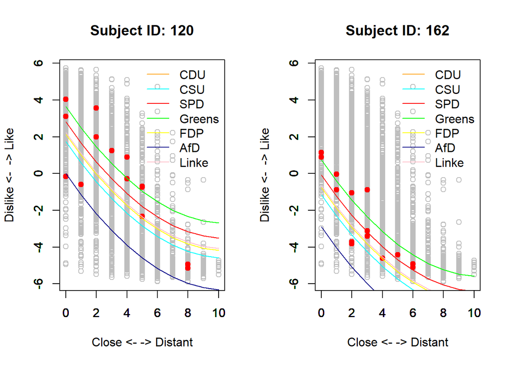

```r
par(mfrow=c(1,2))
for (i.subj in c(120,162)){

  this.fe <-coef(lm.out.dummy.fe)[grep(as.character(i.subj),
                                       names(coef(lm.out.dummy.fe)))]

  plot(long.data$skalo.true ~ long.data$lr.dist.abs,
     xlab="Close <- -> Distant",ylab="Dislike <-  -> Like",
     xlim=range(long.data$lr.dist.abs,na.rm=T),
     ylim=range(long.data$skalo.true,na.rm=T),col="grey",
     main=paste("Subject ID:",i.subj))
  par(new=T)
  plot(long.data$skalo.true[long.data$subject==i.subj] ~
         long.data$lr.dist.abs[long.data$subject==i.subj],
     ann=F,axes=F,xlab="",ylab="",
     xlim=range(long.data$lr.dist.abs,na.rm=T),
     ylim=range(long.data$skalo.true,na.rm=T),
     col="red",pch=19)

predicted.cdu <- coef(lm.out.dummy)[1] + coef(lm.out.dummy)[2]*c(0:10)+ coef(lm.out.dummy)[3]* (c(0:10))^2 + this.fe
predicted.csu <- coef(lm.out.dummy)[1] + coef(lm.out.dummy)[2]*c(0:10) +coef(lm.out.dummy)[3]* (c(0:10))^2 +coef(lm.out.dummy)[4] + this.fe
predicted.spd <- coef(lm.out.dummy)[1] + coef(lm.out.dummy)[2]*c(0:10) +coef(lm.out.dummy)[3]* (c(0:10))^2 +coef(lm.out.dummy)[5] + this.fe
predicted.gru <- coef(lm.out.dummy)[1] + coef(lm.out.dummy)[2]*c(0:10) +coef(lm.out.dummy)[3]* (c(0:10))^2 +coef(lm.out.dummy)[6] + this.fe
predicted.fdp <- coef(lm.out.dummy)[1] + coef(lm.out.dummy)[2]*c(0:10) +coef(lm.out.dummy)[3]* (c(0:10))^2 +coef(lm.out.dummy)[7] + this.fe
predicted.afd <- coef(lm.out.dummy)[1] + coef(lm.out.dummy)[2]*c(0:10) +coef(lm.out.dummy)[3]* (c(0:10))^2 +coef(lm.out.dummy)[8] + this.fe
predicted.lin <- coef(lm.out.dummy)[1] + coef(lm.out.dummy)[2]*c(0:10) +coef(lm.out.dummy)[3]* (c(0:10))^2 +coef(lm.out.dummy)[9] + this.fe

par(new=T)
plot(predicted.cdu ~ c(0:10),col="orange",type="l",
     ann=F,axes=F,xlab="",ylab="",
     xlim=range(long.data$lr.dist.abs,na.rm=T),
     ylim=range(long.data$skalo.true,na.rm=T))
par(new=T)
plot(predicted.csu ~ c(0:10),col="cyan",type="l",
     ann=F,axes=F,xlab="",ylab="",
     xlim=range(long.data$lr.dist.abs,na.rm=T),
     ylim=range(long.data$skalo.true,na.rm=T))
par(new=T)
plot(predicted.spd ~ c(0:10),col="red",type="l",
     ann=F,axes=F,xlab="",ylab="",
     xlim=range(long.data$lr.dist.abs,na.rm=T),
     ylim=range(long.data$skalo.true,na.rm=T))
par(new=T)
plot(predicted.gru ~ c(0:10),col="green",type="l",
     ann=F,axes=F,xlab="",ylab="",
     xlim=range(long.data$lr.dist.abs,na.rm=T),
     ylim=range(long.data$skalo.true,na.rm=T))
par(new=T)
plot(predicted.fdp ~ c(0:10),col="yellow",type="l",
     ann=F,axes=F,xlab="",ylab="",
     xlim=range(long.data$lr.dist.abs,na.rm=T),
     ylim=range(long.data$skalo.true,na.rm=T))
par(new=T)
plot(predicted.afd ~ c(0:10),col="blue4",type="l",
     ann=F,axes=F,xlab="",ylab="",
     xlim=range(long.data$lr.dist.abs,na.rm=T),
     ylim=range(long.data$skalo.true,na.rm=T))
par(new=T)
plot(predicted.lin ~ c(0:10),col="pink",type="l",
     ann=F,axes=F,xlab="",ylab="",
     xlim=range(long.data$lr.dist.abs,na.rm=T),
     ylim=range(long.data$skalo.true,na.rm=T))


legend("topright",col=c("orange","cyan","red","green","yellow","blue4","pink"),
       lty=c(rep(1,8)),c("CDU","CSU","SPD","Greens","FDP","AfD",
                        "Linke"),
       lwd=c(rep(1,8)),
       bty="n")
}
```

It is obvious that both respondents use the scale for like/dislike differently. Respondent 120 tend to evaluate parties more positively in general than Repondent 162.

One can also check the correlation between ideological distances as independent variable and the estimated fixed effects:

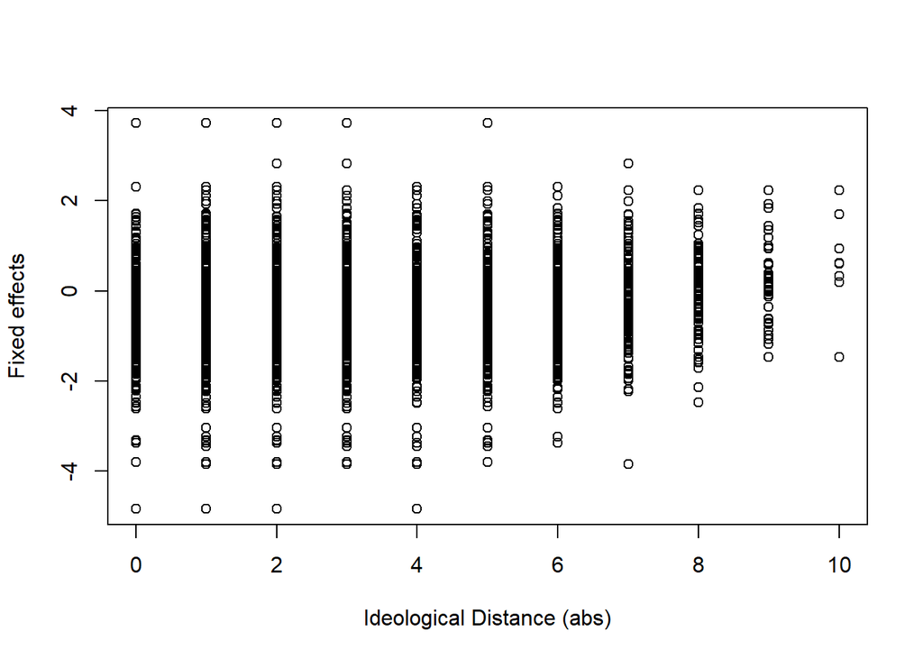

```r
fixed.effects <- coef(lm.out.dummy.fe)[grep("subject",
                                       names(coef(lm.out.dummy.fe)))]
fixed.effects <- c(coef(lm.out.dummy.fe)[1],fixed.effects)
names(fixed.effects) <- unique(long.data$subject)

o <- match(long.data$subject,names(fixed.effects))

long.data$fixed.effects <- fixed.effects[o]


plot(long.data$fixed.effects ~ long.data$lr.dist.abs,
     ylab="Fixed effects",xlab="Ideological Distance (abs)")
```

```r
cor.test(long.data$fixed.effects ,long.data$lr.dist.abs)
```

```
##
##  Pearson's product-moment correlation
##
## data:  long.data$fixed.effects and long.data$lr.dist.abs
## t = 7.3939, df = 3831, p-value = 1.742e-13
## alternative hypothesis: true correlation is not equal to 0
## 95 percent confidence interval:
##  0.08728307 0.14971201
## sample estimates:
##       cor
## 0.1186148
```

```r
cor.test(long.data$fixed.effects ,long.data$lr.dist.sqr)
```

```
##
##  Pearson's product-moment correlation
##
## data:  long.data$fixed.effects and long.data$lr.dist.sqr
## t = 8.3866, df = 3831, p-value < 2.2e-16
## alternative hypothesis: true correlation is not equal to 0
## 95 percent confidence interval:
##  0.1030481 0.1652266
## sample estimates:
##       cor
## 0.1342695
```

The estimated positive correlation is also significant at 5% level. Therefore, the model without the fixed effect is likely to violate the important assumption of the linear regression model.

### First differenced estimator

Another possibility to cope with the individual heterogeneity is to take the first-differences.

In our dataset, each of the respondent-party pairs may have two observations. For example, the first and eighth rows are Respondent 105’s evaluation of CDU (party=1) at two different panel waves.

```r
head(long.data[24:100,1:7],n=20)
```

```
##       id wave party skalo lr.self lr time
## 24 10511    1     1    -5      -2  1   40
## 25 10512    1     2    -5      -2  1   24
## 26 10513    1     3     2      -2 -2   67
## 27 10514    1     4     5      -2 -2   23
## 28 10515    1     5    -5      -2  0   55
## 29 10516    1     6    -5      -2  4   64
## 30 10517    1     7     0      -2 -4   34
## 31 10521    2     1    -1      -2  1   33
## 32 10522    2     2    -3      -2  2  244
## 33 10523    2     3     1      -2 -1   25
## 34 10524    2     4     4      -2 -2  211
## 35 10525    2     5    -3      -2  1   31
## 36 10526    2     6    -5      -2  4   19
## 37 10527    2     7     0      -2 -4   49
## 38 10611    1     1    -2      -2  2   57
## 39 10612    1     2    -4      -2  4   49
## 40 10613    1     3     3      -2 -2   35
## 41 10614    1     4     5      -2 -1  106
## 42 10615    1     5     2      -2  0   69
## 43 10616    1     6    -5      -2  5   41
```

We are now reoganizing the data which only include the adjacent respondent-party pairs and they are grouped in the next rows:

```r
long.data$subject.party <- long.data$subject*10 + long.data$party

long.data <- long.data[order(long.data$subject.party),]

# keeping only adjacent data
freq.subject.party <- table(long.data$subject.party)
adjacent <- as.numeric(names(freq.subject.party[freq.subject.party>=2]))

adjacent.data <- long.data[long.data$subject.party %in% adjacent,]

head(adjacent.data[,1:7],n=20)
```

```
##       id wave party skalo lr.self lr time
## 15 10411    1     1     2       2  2   54
## 17 10421    2     1     2       2  1   26
## 16 10416    1     6     1       2  5   20
## 22 10426    2     6     1       2  3   38
## 24 10511    1     1    -5      -2  1   40
## 31 10521    2     1    -1      -2  1   33
## 25 10512    1     2    -5      -2  1   24
## 32 10522    2     2    -3      -2  2  244
## 26 10513    1     3     2      -2 -2   67
## 33 10523    2     3     1      -2 -1   25
## 27 10514    1     4     5      -2 -2   23
## 34 10524    2     4     4      -2 -2  211
## 28 10515    1     5    -5      -2  0   55
## 35 10525    2     5    -3      -2  1   31
## 29 10516    1     6    -5      -2  4   64
## 36 10526    2     6    -5      -2  4   19
## 30 10517    1     7     0      -2 -4   34
## 37 10527    2     7     0      -2 -4   49
## 38 10611    1     1    -2      -2  2   57
## 45 10621    2     1    -3      -3  1   20
```

From this data, we create the first differences

```r
# creating a wide format data
unique.subject.party <- unique(long.data$subject.party)

diff.data <- NULL
for (i.wave in 1:2){
  dat.t1 <- adjacent.data[adjacent.data$wave==i.wave,
                     c("subject.party","skalo.true",
                       "lr.dist.abs","lr.dist.sqr","party")]
  dat.t2 <- adjacent.data[adjacent.data$wave==i.wave+1,
                     c("subject.party","skalo.true",
                       "lr.dist.abs","lr.dist.sqr","party")]

  o <- match(dat.t1$subject.party,dat.t2$subject.party)

  this.diff.data <- dat.t2[o,] - dat.t1
  this.diff.data$subject.party <- dat.t1$subject.party
  this.diff.data$party <- dat.t1$party
  this.diff.data$wave <- i.wave+1
  this.diff.data <- this.diff.data[!is.na(this.diff.data$skalo.true),]

  diff.data <- rbind(diff.data,
                     this.diff.data
                     )
}


summary(lm(skalo.true ~ lr.dist.abs +lr.dist.sqr + as.factor(party),data=diff.data))
```

```
##
## Call:
## lm(formula = skalo.true ~ lr.dist.abs + lr.dist.sqr + as.factor(party),
##     data = diff.data)
##
## Residuals:
##     Min      1Q  Median      3Q     Max
## -6.6495 -0.7099 -0.0326  0.7524  4.7473
##
## Coefficients:
##                    Estimate Std. Error t value Pr(>|t|)
## (Intercept)        0.058658   0.108953   0.538   0.5904
## lr.dist.abs       -0.159964   0.076219  -2.099   0.0361 *
## lr.dist.sqr        0.005919   0.010482   0.565   0.5724
## as.factor(party)2 -0.161633   0.154988  -1.043   0.2973
## as.factor(party)3  0.140484   0.154179   0.911   0.3624
## as.factor(party)4 -0.204338   0.154140  -1.326   0.1852
## as.factor(party)5  0.245844   0.158874   1.547   0.1221
## as.factor(party)6  0.088338   0.156789   0.563   0.5733
## as.factor(party)7  0.086795   0.154304   0.562   0.5739
## ---
## Signif. codes:  0 '***' 0.001 '**' 0.01 '*' 0.05 '.' 0.1 ' ' 1
##
## Residual standard error: 1.337 on 1017 degrees of freedom
## Multiple R-squared:  0.02188,    Adjusted R-squared:  0.01419
## F-statistic: 2.844 on 8 and 1017 DF,  p-value: 0.003962
```

Now, the coefficients of both ideological distance measures are very small and only the that of the absolute ideological distance measure is significant at 5% more. Here, however, we have to note that we sweeped out individual heterogeneity by first differencing. This strongly reduced the variance of both dependent and independent variables (see the figure below). Furthermore, our independent variables are certainly suffering from measurement errors. The first differencing makes this problem even more serious.

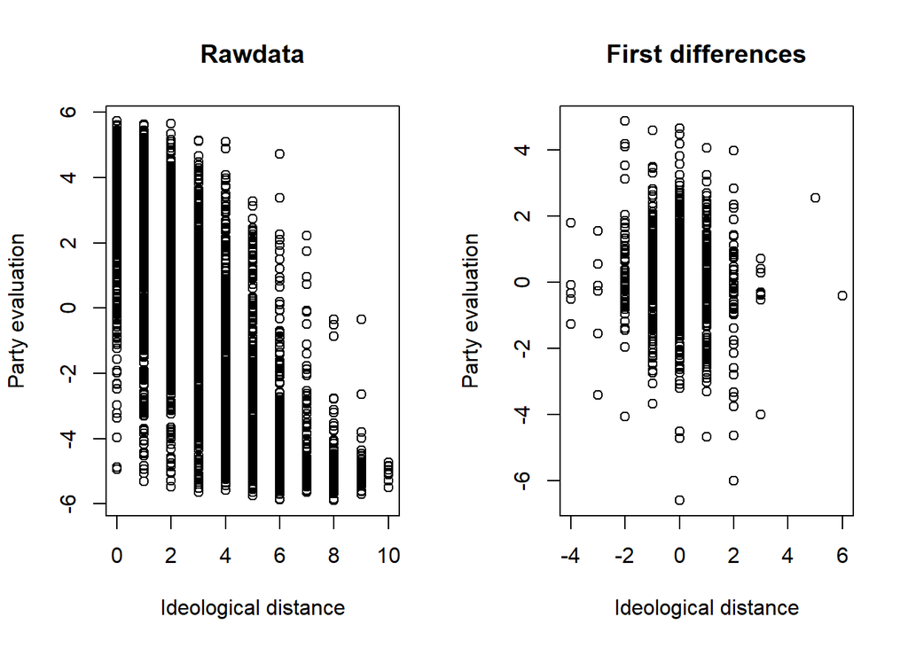

```r
par(mfrow=c(1,2))

plot(long.data$skalo.true ~ long.data$lr.dist.abs,main="Rawdata",
     ylab="Party evaluation",xlab="Ideological distance")
plot(diff.data$skalo.true ~ diff.data$lr.dist.abs,main="First differences",
     ylab="Party evaluation",xlab="Ideological distance")
```

## Censored models

We have already estimated the following model for many times:

```r
summary(lm.out.abs <- lm(skalo.true ~ lr.dist.abs,data=long.data))
```

```
##
## Call:
## lm(formula = skalo.true ~ lr.dist.abs, data = long.data)
##
## Residuals:
##     Min      1Q  Median      3Q     Max
## -7.9169 -1.4955  0.1624  1.4471  8.1145
##
## Coefficients:
##             Estimate Std. Error t value Pr(>|t|)
## (Intercept)  2.98875    0.05586    53.5   <2e-16 ***
## lr.dist.abs -1.06374    0.01490   -71.4   <2e-16 ***
## ---
## Signif. codes:  0 '***' 0.001 '**' 0.01 '*' 0.05 '.' 0.1 ' ' 1
##
## Residual standard error: 2.109 on 3831 degrees of freedom
## Multiple R-squared:  0.571,  Adjusted R-squared:  0.5709
## F-statistic:  5098 on 1 and 3831 DF,  p-value: < 2.2e-16
```

```r
plot(long.data$skalo.true ~ long.data$lr.dist.abs,
     xlab="Ideological Distance (abs)",
     ylab="Like/Dislike (true value)")
abline(lm.out.abs)
```

[output not shown]

In the very early session, we created the dependent variable under the assumption of random measurement errors from a survey item. If we use the original survey variable, you will obtain the following results:

```r
summary(lm.out.abs0 <- lm(skalo ~ lr.dist.abs,data=long.data))
```

```
##
## Call:
## lm(formula = skalo ~ lr.dist.abs, data = long.data)
##
## Residuals:
##     Min      1Q  Median      3Q     Max
## -7.9671 -1.6116  0.1514  1.2699  8.3884
##
## Coefficients:
##             Estimate Std. Error t value Pr(>|t|)
## (Intercept)  2.96714    0.05552   53.44   <2e-16 ***
## lr.dist.abs -1.05926    0.01481  -71.54   <2e-16 ***
## ---
## Signif. codes:  0 '***' 0.001 '**' 0.01 '*' 0.05 '.' 0.1 ' ' 1
##
## Residual standard error: 2.096 on 3831 degrees of freedom
## Multiple R-squared:  0.5719, Adjusted R-squared:  0.5718
## F-statistic:  5118 on 1 and 3831 DF,  p-value: < 2.2e-16
```

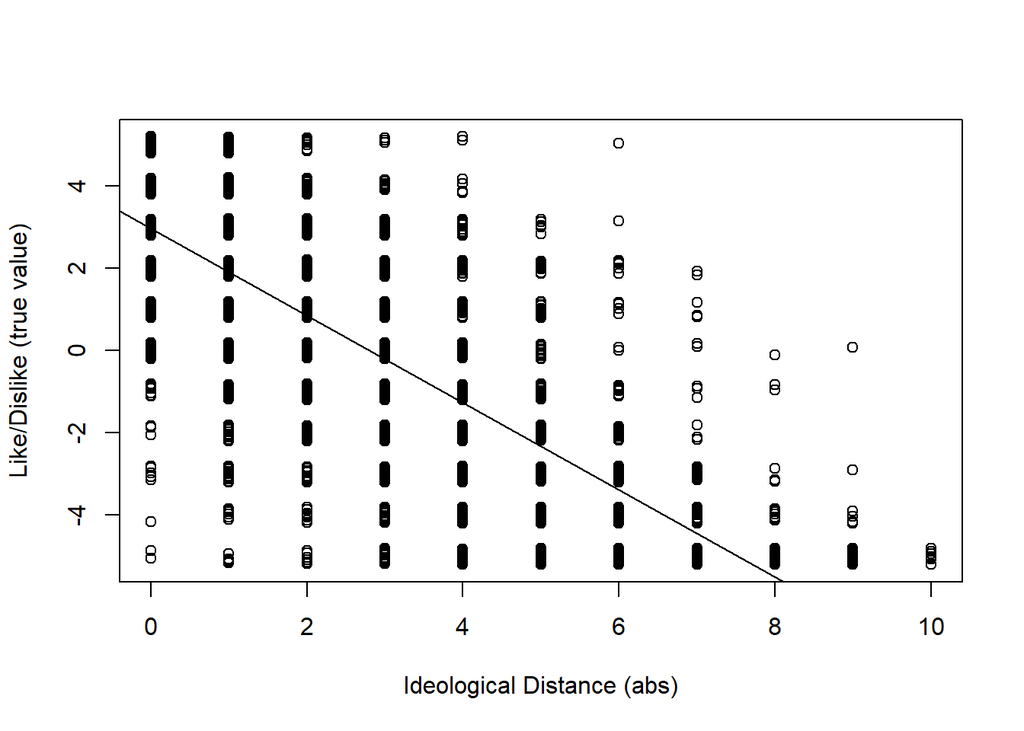

```r
plot(jitter(long.data$skalo) ~ long.data$lr.dist.abs,
     xlab="Ideological Distance (abs)",
     ylab="Like/Dislike (true value)")
abline(lm.out.abs0)
```

The original variable of party evaluation was measured by using a scale from -5 to +5. However, the predicted values for x=8 or larger are outside of the range.

Now we can conceive that the party evaluation measure is censored. That is, we assume that among those who rated a party with +5, there are some respondents who would have rated the party with +6 or more. And the same can be also assumed for those who rated a party with -5. This idea is behind the censored regression models:

```r
library(censReg)
summary(cens.out.abs <- censReg(skalo ~ lr.dist.abs,
                                left=-5,right=5,
                                data=long.data))
```

```
##
## Call:
## censReg(formula = skalo ~ lr.dist.abs, left = -5, right = 5,
##     data = long.data)
##
## Observations:
##          Total  Left-censored     Uncensored Right-censored
##           3833            587           3093            153
##
## Coefficients:
##             Estimate Std. error t value Pr(> t)
## (Intercept)  3.48254    0.06744   51.64  <2e-16 ***
## lr.dist.abs -1.32118    0.01986  -66.53  <2e-16 ***
## logSigma     0.88399    0.01311   67.40  <2e-16 ***
## ---
## Signif. codes:  0 '***' 0.001 '**' 0.01 '*' 0.05 '.' 0.1 ' ' 1
##
## Newton-Raphson maximisation, 5 iterations
## Return code 1: gradient close to zero (gradtol)
## Log-likelihood: -7718.408 on 3 Df
```

The result of the censored model can be compared with the simple linear regression model in the following figure:

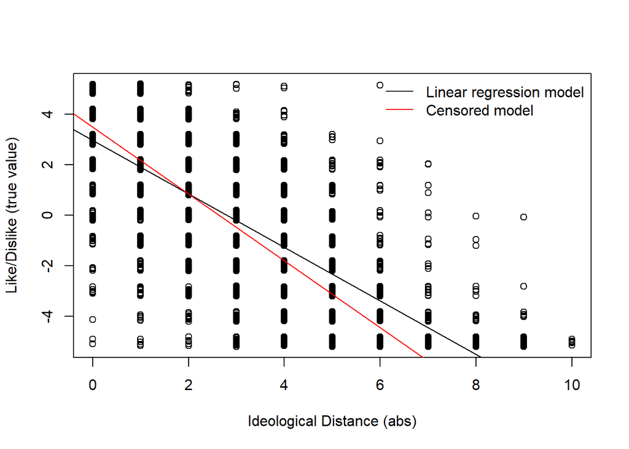

```r
plot(jitter(long.data$skalo) ~ long.data$lr.dist.abs,
     xlab="Ideological Distance (abs)",
     ylab="Like/Dislike (true value)")
abline(lm.out.abs0)
abline(coef=cens.out.abs$estimate[1:2],col="red")
legend("topright",lty=1,
       col=c("black","red"),
       legend=c("Linear regression model","Censored model"),
       bty="n")
```

The difference is in particular clear in the region with a large ideological distance (x>6). While the censored model assumes smaller values behind the measurement of y=-5, the linear regression model takes all the measurement value as face value. Therefore, the latter is more flat to minimize the residuals. In contrast, the slope of the censored model is steeper since the range of the dependent variable does not play a role.

We can now extend the model with the party-dummy variables to consider the heterogeneity among parties:

```r
summary(cens.out.dummy <- censReg(skalo ~ lr.dist.abs+as.factor(party),
                                left=-5,right=5,
                                data=long.data))
```

```
##
## Call:
## censReg(formula = skalo ~ lr.dist.abs + as.factor(party), left = -5,
##     right = 5, data = long.data)
##
## Observations:
##          Total  Left-censored     Uncensored Right-censored
##           3833            587           3093            153
##
## Coefficients:
##                   Estimate Std. error t value  Pr(> t)
## (Intercept)        2.66054    0.11222  23.709  < 2e-16 ***
## lr.dist.abs       -0.96307    0.02226 -43.267  < 2e-16 ***
## as.factor(party)2 -0.42768    0.13561  -3.154 0.001612 **
## as.factor(party)3  0.51802    0.13619   3.804 0.000142 ***
## as.factor(party)4  1.50855    0.13754  10.968  < 2e-16 ***
## as.factor(party)5 -0.12022    0.13499  -0.891 0.373133
## as.factor(party)6 -4.08257    0.18494 -22.075  < 2e-16 ***
## as.factor(party)7 -0.09731    0.13378  -0.727 0.467000
## logSigma           0.79358    0.01301  61.014  < 2e-16 ***
## ---
## Signif. codes:  0 '***' 0.001 '**' 0.01 '*' 0.05 '.' 0.1 ' ' 1
##
## Newton-Raphson maximisation, 5 iterations
## Return code 8: successive function values within relative tolerance limit (reltol)
## Log-likelihood: -7285.874 on 9 Df
```

We can further include the quadratic function:

```r
summary(cens.out.dummy.quad <- censReg(skalo ~ lr.dist.abs+
                                  lr.dist.sqr +
                                  as.factor(party),
                                left=-5,right=5,
                                data=long.data))
```

```
##
## Call:
## censReg(formula = skalo ~ lr.dist.abs + lr.dist.sqr + as.factor(party),
##     left = -5, right = 5, data = long.data)
##
## Observations:
##          Total  Left-censored     Uncensored Right-censored
##           3833            587           3093            153
##
## Coefficients:
##                    Estimate Std. error t value  Pr(> t)
## (Intercept)        2.725252   0.127395  21.392  < 2e-16 ***
## lr.dist.abs       -1.022759   0.059960 -17.057  < 2e-16 ***
## lr.dist.sqr        0.009153   0.008525   1.074 0.282995
## as.factor(party)2 -0.433356   0.135591  -3.196 0.001393 **
## as.factor(party)3  0.506663   0.136494   3.712 0.000206 ***
## as.factor(party)4  1.489528   0.138583  10.748  < 2e-16 ***
## as.factor(party)5 -0.120501   0.134879  -0.893 0.371643
## as.factor(party)6 -4.109909   0.186335 -22.057  < 2e-16 ***
## as.factor(party)7 -0.093428   0.133720  -0.699 0.484747
## logSigma           0.792813   0.013021  60.887  < 2e-16 ***
## ---
## Signif. codes:  0 '***' 0.001 '**' 0.01 '*' 0.05 '.' 0.1 ' ' 1
##
## Newton-Raphson maximisation, 5 iterations
## Return code 1: gradient close to zero (gradtol)
## Log-likelihood: -7285.301 on 10 Df
```

Interestingly, the coefficient of the quadratic distance is not significant (at 5%-level). If we compare this model with the last one in the log-likelihood, the improvement is very small and it is not significant at 5%-level.

This result is reasonable if we consider that the linear model with the quadratic term lead to a convex function. This convex function predicted higher values in party evaluation for those with larger ideological distances. This was an artifact due to the censored dependent variable.

Further, we can extend the previous model (without the quadratic distance) by including the fixed effects for respondents:

```r
summary(cens.out.dummy.fe <- censReg(skalo ~ lr.dist.abs+as.factor(party)+
                                    as.factor(subject),
                                left=-5,right=5,
                                data=long.data))
```

```
##
## Call:
## censReg(formula = skalo ~ lr.dist.abs + as.factor(party) + as.factor(subject),
##     left = -5, right = 5, data = long.data)
##
## Observations:
##          Total  Left-censored     Uncensored Right-censored
##           3833            587           3093            153
##
## Coefficients:
##                        Estimate Std. error t value  Pr(> t)
## (Intercept)            2.866106   0.715947   4.003 6.25e-05 ***
## lr.dist.abs           -1.050773   0.021199 -49.566  < 2e-16 ***
## as.factor(party)2     -0.323844   0.115997  -2.792 0.005241 **
## as.factor(party)3      0.413375   0.116636   3.544 0.000394 ***
## as.factor(party)4      1.370361   0.117969  11.616  < 2e-16 ***
## as.factor(party)5     -0.113547   0.115140  -0.986 0.324049
## as.factor(party)6     -3.632724   0.166455 -21.824  < 2e-16 ***
## as.factor(party)7     -0.065541   0.114098  -0.574 0.565678
## as.factor(subject)102 -1.007253   1.005158  -1.002 0.316303
## as.factor(subject)104  1.150830   0.947792   1.214 0.224663
## as.factor(subject)105 -2.047462   0.900743  -2.273 0.023021 *
## as.factor(subject)106  0.122968   0.896698   0.137 0.890925
## as.factor(subject)107  2.031656   1.032508   1.968 0.049104 *
## as.factor(subject)109  0.251422   0.893596   0.281 0.778434
## as.factor(subject)110  0.378739   1.050335   0.361 0.718407
## as.factor(subject)111  1.108717   0.904964   1.225 0.220519
## as.factor(subject)112  0.841080   1.034575   0.813 0.416235
## as.factor(subject)113 -0.051394   0.891972  -0.058 0.954053
## as.factor(subject)114 -0.801659   0.893341  -0.897 0.369521
## as.factor(subject)115 -0.958019   1.022296  -0.937 0.348695
## as.factor(subject)116  0.459671   0.889007   0.517 0.605113
## as.factor(subject)117 -2.005863   1.068678  -1.877 0.060524 .
## as.factor(subject)118 -0.466165   0.889082  -0.524 0.600055
## as.factor(subject)119 -1.241852   0.891519  -1.393 0.163632
## as.factor(subject)120  0.450204   0.891612   0.505 0.613606
## as.factor(subject)121  0.967939   0.884096   1.095 0.273589
## as.factor(subject)122 -0.269770   0.873118  -0.309 0.757342
## as.factor(subject)123 -0.328577   0.882372  -0.372 0.709611
## as.factor(subject)124 -0.682328   1.035626  -0.659 0.509989
```

[output cut: 378 more lines]

```
## as.factor(subject)513 -0.883151   1.030035  -0.857 0.391225
## as.factor(subject)514  2.072439   0.888288   2.333 0.019644 *
## as.factor(subject)515 -0.546488   1.027997  -0.532 0.595000
## as.factor(subject)516 -1.141236   1.038557  -1.099 0.271826
## as.factor(subject)517 -0.798422   0.890260  -0.897 0.369803
## as.factor(subject)518 -1.588928   1.046758  -1.518 0.129027
## as.factor(subject)527 -0.262240   1.055886  -0.248 0.803855
## as.factor(subject)529 -0.714286   1.005154  -0.711 0.477318
## logSigma               0.631522   0.012975  48.672  < 2e-16 ***
## ---
## Signif. codes:  0 '***' 0.001 '**' 0.01 '*' 0.05 '.' 0.1 ' ' 1
##
## Newton-Raphson maximisation, 7 iterations
## Return code 8: successive function values within relative tolerance limit (reltol)
## Log-likelihood: -6750.522 on 416 Df
```

We can check whether we should include the fixed effect by using the likelihood ratio test. First, we check the log-likelihood values of both models:

```r
print('Model without FE')
```

```
## [1] "Model without FE"
```

```r
logLik(cens.out.dummy)
```

```
## 'log Lik.' -7285.874 (df=9)
```

```r
print('Model with FE')
```

```
## [1] "Model with FE"
```

```r
logLik(cens.out.dummy.fe)
```

```
## 'log Lik.' -6750.522 (df=416)
```

We calculate the log-likelihood ratio and compare it with the chi-square distribution

```r
print('log likelihood ratio')
```

```
## [1] "log likelihood ratio"
```

```r
-2*(as.numeric(logLik(cens.out.dummy)) -
as.numeric(logLik(cens.out.dummy.fe)) )
```

```
## [1] 1070.705
```

```r
print('critical value for p=0.95')
```

```
## [1] "critical value for p=0.95"
```

```r
qchisq(0.95,df=
(attributes(logLik(cens.out.dummy.fe))$df-
                                            attributes(logLik(cens.out.dummy))$df)
)
```

```
## [1] 455.038
```

Since the log-likelihood ratio exceeds the critical value, we can reject the null-hypothesis that both models’ are at the same level in their performance. In other words, the model with fixed effects has significantly better performance than the model without fixed effects.

Now we can check again the two respondents whose predicted values have already demonstrated in the non-censored linear model (see the section for the panel data analysis):

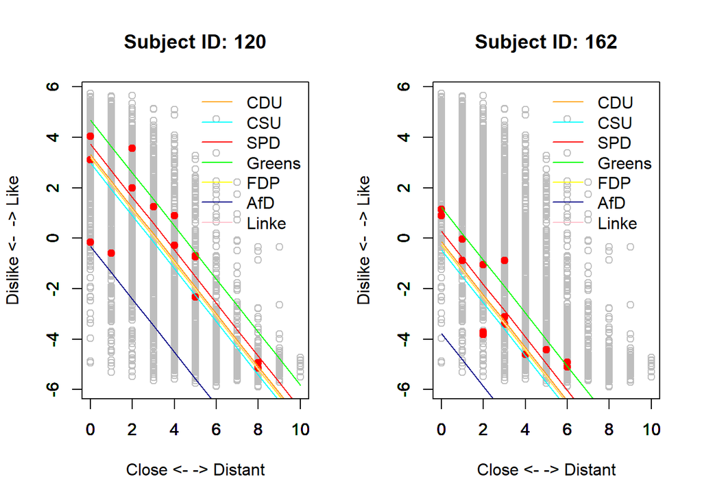

```r
par(mfrow=c(1,2))
for (i.subj in c(120,162)){

  this.fe <-coef(cens.out.dummy.fe)[grep(as.character(i.subj),
                                       names(coef(cens.out.dummy.fe)))]

  plot(long.data$skalo.true ~ long.data$lr.dist.abs,
     xlab="Close <- -> Distant",ylab="Dislike <-  -> Like",
     xlim=range(long.data$lr.dist.abs,na.rm=T),
     ylim=range(long.data$skalo.true,na.rm=T),col="grey",
     main=paste("Subject ID:",i.subj))
  par(new=T)
  plot(long.data$skalo.true[long.data$subject==i.subj] ~
         long.data$lr.dist.abs[long.data$subject==i.subj],
     ann=F,axes=F,xlab="",ylab="",
     xlim=range(long.data$lr.dist.abs,na.rm=T),
     ylim=range(long.data$skalo.true,na.rm=T),
     col="red",pch=19)

predicted.cdu <- coef(cens.out.dummy.fe)[1] + coef(cens.out.dummy.fe)[2]*c(0:10)+  this.fe
predicted.csu <- coef(cens.out.dummy.fe)[1] + coef(cens.out.dummy.fe)[2]*c(0:10) +coef(cens.out.dummy.fe)[3] + this.fe
predicted.spd <- coef(cens.out.dummy.fe)[1] + coef(cens.out.dummy.fe)[2]*c(0:10) +coef(cens.out.dummy.fe)[4] + this.fe
predicted.gru <- coef(cens.out.dummy.fe)[1] + coef(cens.out.dummy.fe)[2]*c(0:10) +coef(cens.out.dummy.fe)[5] + this.fe
predicted.fdp <- coef(cens.out.dummy.fe)[1] + coef(cens.out.dummy.fe)[2]*c(0:10) +coef(cens.out.dummy.fe)[6] + this.fe
predicted.afd <- coef(cens.out.dummy.fe)[1] + coef(cens.out.dummy.fe)[2]*c(0:10) +coef(cens.out.dummy.fe)[7] + this.fe
predicted.lin <- coef(cens.out.dummy.fe)[1] + coef(cens.out.dummy.fe)[2]*c(0:10) +coef(cens.out.dummy.fe)[8] + this.fe

par(new=T)
plot(predicted.cdu ~ c(0:10),col="orange",type="l",
     ann=F,axes=F,xlab="",ylab="",
     xlim=range(long.data$lr.dist.abs,na.rm=T),
     ylim=range(long.data$skalo.true,na.rm=T))
par(new=T)
plot(predicted.csu ~ c(0:10),col="cyan",type="l",
     ann=F,axes=F,xlab="",ylab="",
     xlim=range(long.data$lr.dist.abs,na.rm=T),
     ylim=range(long.data$skalo.true,na.rm=T))
par(new=T)
plot(predicted.spd ~ c(0:10),col="red",type="l",
     ann=F,axes=F,xlab="",ylab="",
     xlim=range(long.data$lr.dist.abs,na.rm=T),
     ylim=range(long.data$skalo.true,na.rm=T))
par(new=T)
plot(predicted.gru ~ c(0:10),col="green",type="l",
     ann=F,axes=F,xlab="",ylab="",
     xlim=range(long.data$lr.dist.abs,na.rm=T),
     ylim=range(long.data$skalo.true,na.rm=T))
par(new=T)
plot(predicted.fdp ~ c(0:10),col="yellow",type="l",
     ann=F,axes=F,xlab="",ylab="",
     xlim=range(long.data$lr.dist.abs,na.rm=T),
     ylim=range(long.data$skalo.true,na.rm=T))
par(new=T)
plot(predicted.afd ~ c(0:10),col="blue4",type="l",
     ann=F,axes=F,xlab="",ylab="",
     xlim=range(long.data$lr.dist.abs,na.rm=T),
     ylim=range(long.data$skalo.true,na.rm=T))
par(new=T)
plot(predicted.lin ~ c(0:10),col="pink",type="l",
     ann=F,axes=F,xlab="",ylab="",
     xlim=range(long.data$lr.dist.abs,na.rm=T),
     ylim=range(long.data$skalo.true,na.rm=T))


legend("topright",col=c("orange","cyan","red","green","yellow","blue4","pink"),
       lty=c(rep(1,8)),c("CDU","CSU","SPD","Greens","FDP","AfD",
                        "Linke"),
       lwd=c(rep(1,8)),
       bty="n")
}
```

```r
knitr::knit_exit()
```